# ARIMAX-GARCH pada Data Saham ANTM.JK

Kelompok 1 MPDW

2023-11-23

## Packages

```r
library(readxl)
library(TTR)
library(forecast)
library(tseries)
library(TSA)
library(dynlm)
library(lmtest)
library(imputeTS)
library(stats)
library(MASS)
library(padr)
library(astsa)
library(tfarima)
library(FinTS)
```

```r
library(rio)
library(ggplot2)
library(tsibble)
library(tseries)
library(MASS)
library(dplyr)
library(TTR)
library(forecast)
library(lmtest)
library(orcutt)
library(HoRM)
library(dLagM)
library(dynlm)
library(MLmetrics)
library(car)
library(TSA)
library(aTSA)
library (rio)
library(rugarch)
```

## Pre Processing Data

### Input Data

Data yang digunakan adalah Harga Penutupan Saham ANTAM mingguan dengan total 305 periode, yaitu mulai dari tanggal 1 Januari 2018 sampai 30 Oktober 2023

```r
library(readxl)
data <- read_excel("E:/kuliah/Semester 5/Metode Peramalan Deret Waktu/PraktikumMPDW/ARIMAX-ARCHGARCH/Harga Close Saham ANTAM.xlsx")
data
```

```
## # A tibble: 305 × 2
##    Date                Close
##    <dttm>              <dbl>
##  1 2018-01-01 00:00:00   655
##  2 2018-01-08 00:00:00   665
##  3 2018-01-15 00:00:00   760
##  4 2018-01-22 00:00:00   855
##  5 2018-01-29 00:00:00   905
##  6 2018-02-05 00:00:00   830
##  7 2018-02-12 00:00:00   910
##  8 2018-02-19 00:00:00   895
##  9 2018-02-26 00:00:00   920
## 10 2018-03-05 00:00:00   850
## # ℹ 295 more rows
```

### Mengecek Keberadaan Missing Value

```r
data[which(is.na(data$Close)),]
```

```
## # A tibble: 0 × 2
## # ℹ 2 variables: Date <dttm>, Close <dbl>
```

Tidak ada missing value pada data yang digunakan

### Mengubah Data Menjadi Data Time Series

```r
library(utils)
data.ts <- ts(data$Close)
data.ts
```

```
## Time Series:
## Start = 1
## End = 305
## Frequency = 1
##   [1]  655  665  760  855  905  830  910  895  920  850  845  790  775  805  880
##  [16]  885  860  830  810  850  870  865  905  905  910  890  780  910  870  900
##  [31]  900  895  830  875  870  795  800  820  845  800  795  765  725  695  700
##  [46]  680  625  615  725  755  770  765  760  790  850  930  960 1025  950 1055
##  [61] 1055  990  980  960  890  900  880  885  875  790  745  670  730  725  725
##  [76]  790  800  845  810  845  940  890  900 1065 1120 1015 1070 1075 1070 1065
##  [91]  990  960 1015  935  955  855  835  825  810  750  810  850  830  835  850
## [106]  885  840  785  720  730  675  700  575  610  490  374  460  464  520  520
## [121]  494  510  535  520  520  535  590  580  610  605  600  645  660  685  730
## [136]  840  785  795  820  825  775  790  730  725  765  940 1085 1055 1125 1170
## [151] 1210 1230 1245 1450 1950 1790 1935 2600 3120 2880 2220 2660 2870 2880 2840
## [166] 2420 2420 2250 2430 2240 2340 2390 2320 2490 2620 2670 2330 2460 2430 2480
## [181] 2230 2300 2220 2590 2620 2620 2520 2330 2380 2280 2260 2350 2590 2400 2290
## [196] 2220 2340 2470 2430 2340 2360 2400 2390 2340 2340 2320 2250 2280 2250 2230
## [211] 1950 1945 1770 1810 1845 2090 2220 2450 2520 2390 2660 2510 2800 2780 2740
## [226] 2600 2600 2330 2490 2470 2500 2290 2110 1970 1750 1715 1540 1780 1955 2020
## [241] 2220 2060 1955 1900 1975 2040 2040 1940 1935 1820 1800 1835 1915 2120 1960
## [256] 1950 2040 1935 2020 2000 1985 1985 2150 2320 2300 2330 2220 2090 2000 1995
## [271] 1880 1895 1895 2090 2100 2110 2100 2100 2040 2000 1955 1920 1895 1975 2060
## [286] 2010 1950 1975 2000 1975 1960 2020 1990 1950 1990 1955 1945 1900 1850 1815
## [301] 1715 1755 1825 1725 1705
```

## Eksplorasi Data

### Plot Data Penuh

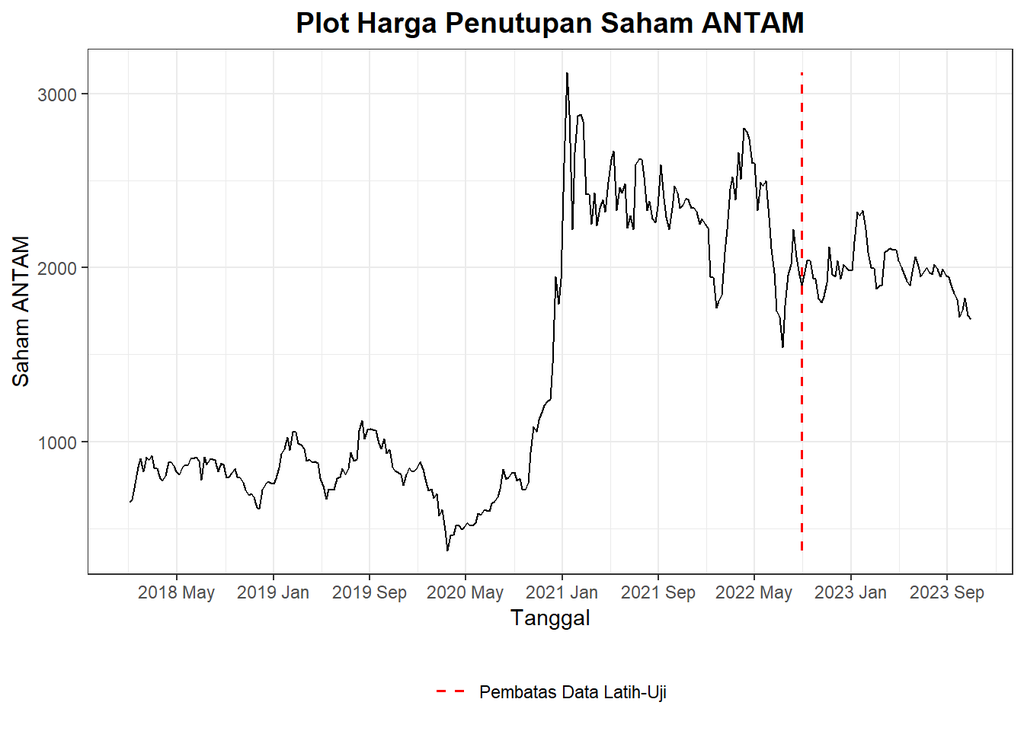

```r
library(ggplot2)

data$Date <- as.Date(data$Date)

# Tentukan indeks pembatas antara data train dan data test
index_pemisah <- 244

# Plot menggunakan ggplot2
ggplot(data, aes(x = Date, y = Close)) +
  geom_line() +
  geom_line(data = data.frame(x = data$Date[index_pemisah], y = range(data$Close)),
            aes(x = x, y = y, color = "Pembatas Data Latih-Uji"),
            linetype = "dashed", linewidth = 0.6) +
  scale_x_date(date_breaks = "8 months", date_labels = "%Y %b") +
  labs(title = "Plot Harga Penutupan Saham ANTAM", x = "Tanggal", y = "Saham ANTAM", color = "") +
  theme_bw() +
  theme(plot.title = element_text(face = "bold", size = 14, hjust = 0.5),
        plot.caption = element_text(hjust = 0.5, size = 12),
        legend.position = "bottom",
        legend.title = element_blank(),
        legend.direction = "vertical") +
  scale_color_manual(values = "red", name = "Pembatas Data Latih-Uji",
                     guide = guide_legend(override.aes = list(linetype = "dashed", angle = 180, size = 1.5)))
```

Berdasarkan plot data deret waktu, terlihat bahwa data cenderung memiliki trend yang naik. Berdasarkan pola data, pembagian data latih dan data uji ditetapkan dengan proporsi 80%:20% sehingga 244 periode untuk data latih dan 61 periode untuk data uji.

### Pembagian Data

```r
data.train <- data[1:244,]
data.ts.train <- data.ts[1:244]
data.test <- data[245:305,]
data.ts.test <- data.ts[245:305]
```

### Plot Data Latih

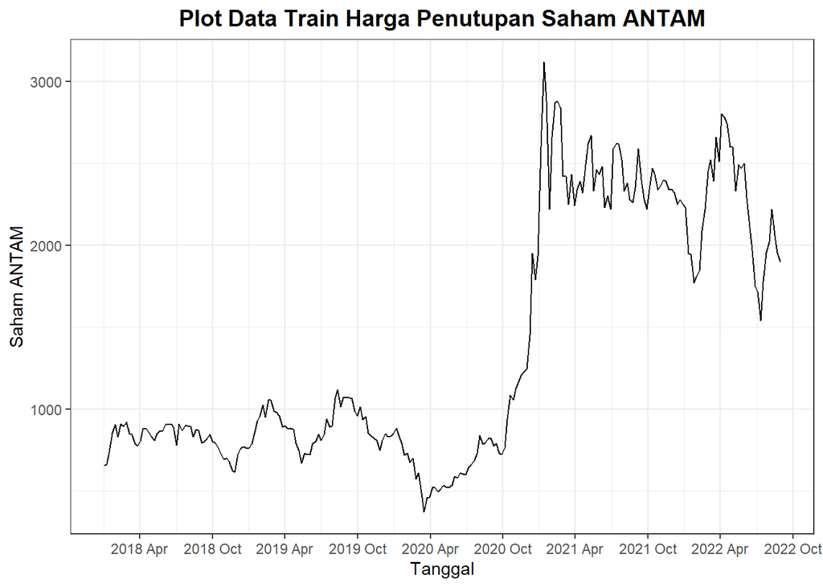

```r
library(ggplot2)
ggplot() +
  geom_line(data = data.train, aes(x=Date, y=Close)) +
  labs(title = "Plot Data Train Harga Penutupan Saham ANTAM", x = "Tanggal", y = "Saham ANTAM", color = "Legend") + scale_x_date(date_breaks = "6 months", date_labels = "%Y %b") +
  theme_bw() + theme(plot.title = element_text(face = "bold", size = 14, hjust = 0.5),
                     plot.caption = element_text(hjust=0.5, size=12)) +
  scale_color_manual(values = "black")
```

Berdasarkan plot data deret waktu pada data latih, terlihat bahwa data cenderung tidak bergerak pada nilai tengah tertentu. Hal ini mengindikasikan bahwa data tidak stasioner dalam rataan. Mulai periode ke-154 yaitu tanggal 7 Desember 2020, nilai harga penutupan saham ANTAM naik secara signifikan. Hal ini menjadi alasan untuk penggunaan model ARIMAX. Plot data deret waktu juga cenderung fluktuatif dengan ragam yang tidak konstan sehingga dapat dikatakan bahwa data tidak stasioner dalam ragam.

### Plot Data Uji

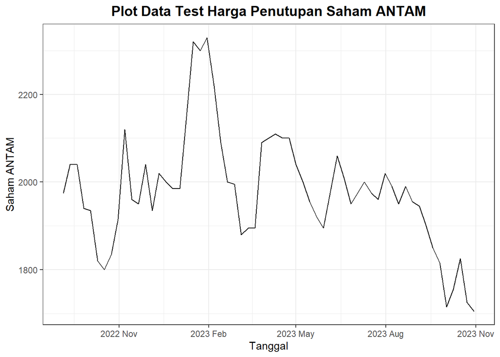

```r
library(ggplot2)
ggplot() +
  geom_line(data = data.test, aes(x=Date, y=Close)) +
  labs(title = "Plot Data Test Harga Penutupan Saham ANTAM", x = "Tanggal", y = "Saham ANTAM", color = "Legend") + scale_x_date(date_breaks = "3 months", date_labels = "%Y %b") +
  theme_bw() + theme(plot.title = element_text(face = "bold", size = 14, hjust = 0.5),
                     plot.caption = element_text(hjust=0.5, size=12)) +
  scale_color_manual(values = "black")
```

Berdasarkan plot data deret waktu pada data uji, terlihat bahwa data cenderung fluktuatif.

## Uji Stasioneritas Data

### 1. Uji Kestasioneran dalam Rataan

### Plot ACF

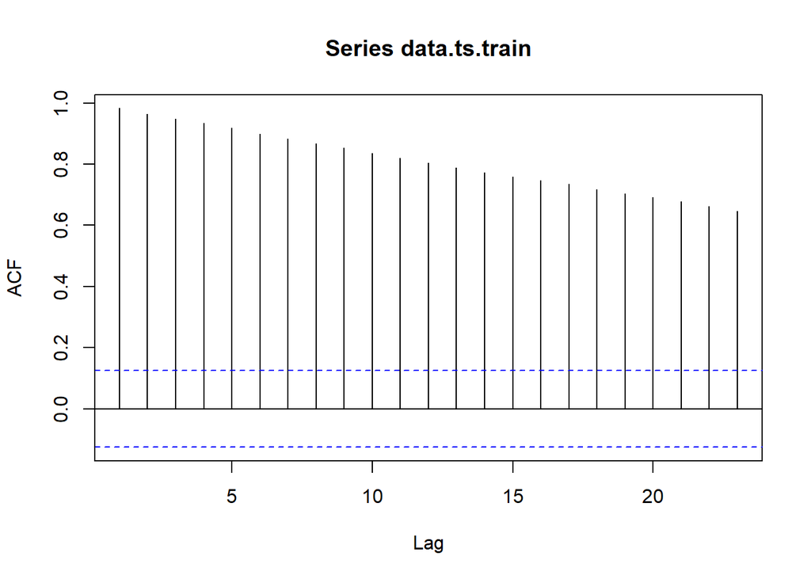

```r
acf(data.ts.train)
```

Berdasarkan plot ACF, terlihat bahwa plot ACF data menurun secara perlahan (*tails of slowly*). Hal ini juga menjadi indikasi bahwa data tidak stasioner dalam rataan.

### Uji ADF

```r
tseries::adf.test(data.ts.train)
```

```
##
##  Augmented Dickey-Fuller Test
##
## data:  data.ts.train
## Dickey-Fuller = -2.163, Lag order = 6, p-value = 0.5073
## alternative hypothesis: stationary
```

$H_0$ : Data tidak stasioner dalam rataan

$H_1$ : Data stasioner dalam rataan

Berdasarkan uji ADF tersebut, didapat *p-value* sebesar 0.5073 yang lebih besar dari taraf nyata 5% sehingga tak tolak $H_0$ dan menandakan bahwa data tidak stasioner dalam rataan. Hal ini sesuai dengan hasil eksplorasi menggunakan plot data deret waktu dan plot ACF, sehingga ketidakstasioneran model dalam rataan kedepannya harus ditangani.

### 2. Uji Kestasioneran dalam Ragam

### Plot Box-Cox

```r
index <- seq(1:244)
bc = boxcox(data.ts.train~index, lambda = seq(-2,2,by=1))
```

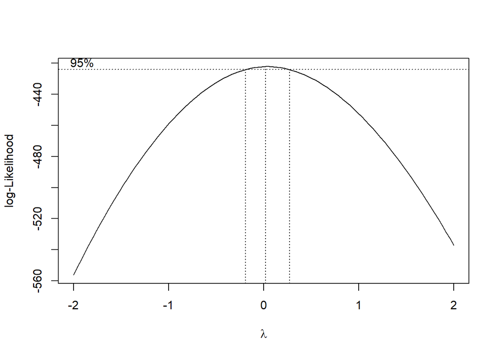

```r
#Nilai Rounded Lambda
lambda <- bc$x[which.max(bc$y)]
lambda
```

```
## [1] 0.02020202
```

```r
#SK
bc$x[bc$y > max(bc$y) - 1/2 * qchisq(.95,1)]
```

```
##  [1] -0.18181818 -0.14141414 -0.10101010 -0.06060606 -0.02020202  0.02020202
##  [7]  0.06060606  0.10101010  0.14141414  0.18181818  0.22222222  0.26262626
```

Plot Box-Cox menunjukkan nilai *rounded value* ($\lambda$) optimum sebesar **0.02020202** dan pada selang kepercayaan 95% nilai memiliki batas bawah **-0.18181818** dan batas atas **0.26262626**. Selang tersebut tidak memuat nilai satu sehingga dapat dikatakan bahwa data tidak stasioner dalam ragam.

## Penanganan Ketidakstasioneran Data

### Ketidakstasioneran dalam Ragam

Dalam selang kepercayaan 95% berdasarkan plot Box-Cox terdapat nilai 0. Oleh karena itu, dilakukan transformasi Box-Cox dengan menggunakan logaritma.

```r
data.trans <- log(data$Close)
train.trans <- log(data.ts.train)
test.trans <- log(data.ts.test)
```

### Plot Box-Cox

```r
index <- seq(1:244)
bc = boxcox(train.trans~index, lambda = seq(-7,10,by=1))
```

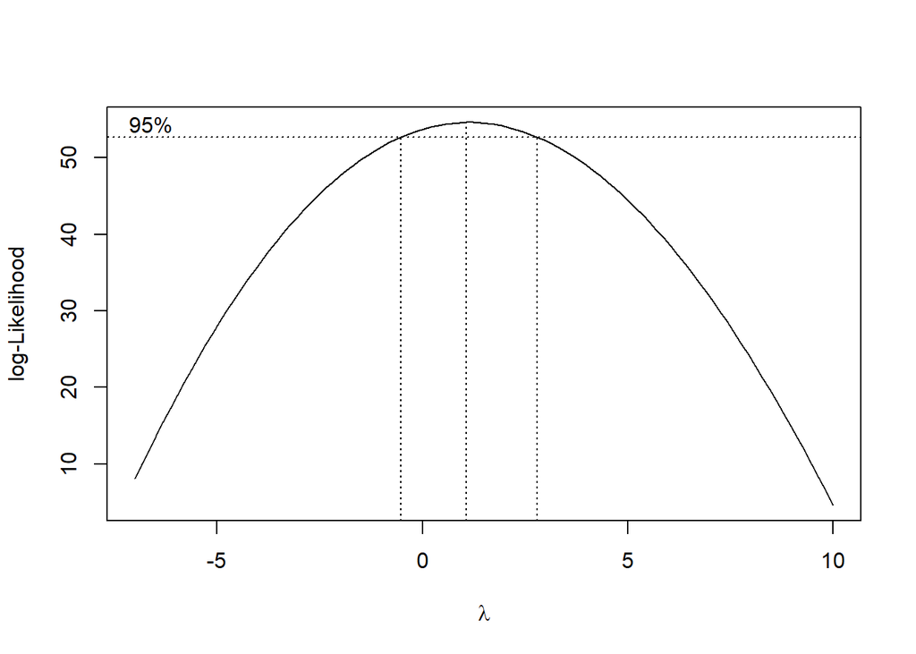

```r
#Nilai Rounded Lambda
lambda <- bc$x[which.max(bc$y)]
lambda
```

```
## [1] 1.070707
```

```r
#SK
bc$x[bc$y > max(bc$y) - 1/2 * qchisq(.95,1)]
```

```
##  [1] -0.47474747 -0.30303030 -0.13131313  0.04040404  0.21212121  0.38383838
##  [7]  0.55555556  0.72727273  0.89898990  1.07070707  1.24242424  1.41414141
## [13]  1.58585859  1.75757576  1.92929293  2.10101010  2.27272727  2.44444444
## [19]  2.61616162  2.78787879
```

Plot Boxcox menunjukkan nilai *rounded value* ($\lambda$) optimum sebesar **1.070707** dan pada selang kepercayaan 95% nilai memiliki batas bawah **-0.47474747** dan batas atas **2.78787879**. Selang tersebut memuat nilai 1 sehingga hal ini menandakan data sudah stasioner dalam ragam dan ketidakstasioneran data dalam ragam telah berhasil tertangani.

### Ketidakstasioneran dalam Rataan

### Plot ACF

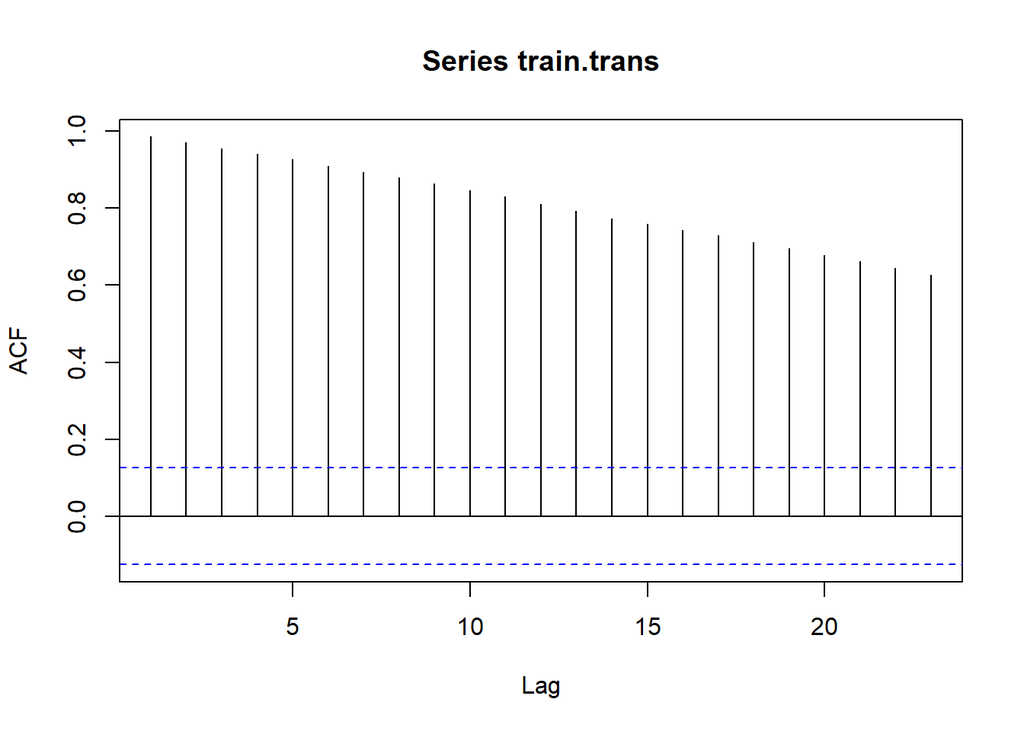

```r
acf(train.trans)
```

Berdasarkan plot ACF, terlihat bahwa plot ACF data menurun secara perlahan (*tails of slowly*). Hal ini menjadi indikasi bahwa data belum stasioner dalam rataan.

### Uji ADF

```r
tseries::adf.test(train.trans)
```

```
##
##  Augmented Dickey-Fuller Test
##
## data:  train.trans
## Dickey-Fuller = -2.0673, Lag order = 6, p-value = 0.5475
## alternative hypothesis: stationary
```

$H_0$ : Data tidak stasioner dalam rataan

$H_1$ : Data stasioner dalam rataan

Berdasarkan uji ADF tersebut, didapat *p-value* sebesar 0.5475 yang lebih besar dari taraf nyata 5% sehingga tak tolak $H_0$ dan menandakan bahwa data tidak stasioner dalam rataan. Hal ini sesuai dengan hasil eksplorasi dengan plot ACF, sehingga ketidakstasioneran model dalam rataan kedepannya harus ditangani.

## Pembedaan sebanyak 1 kali

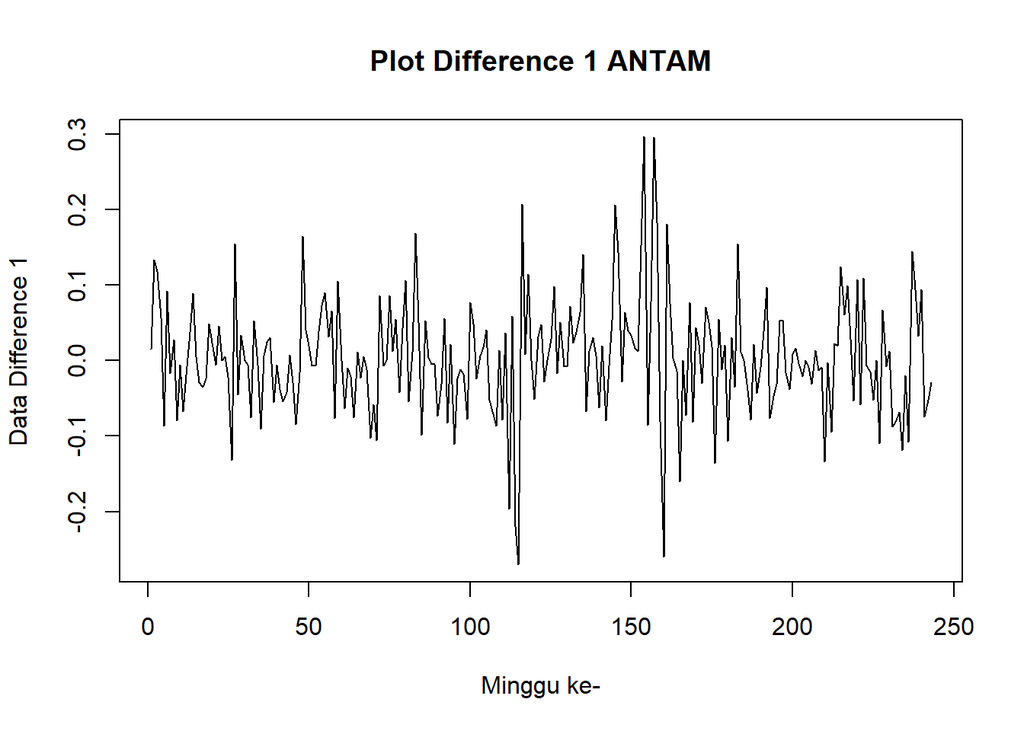

```r
train.diff<-diff(train.trans,differences = 1)
plot.ts(train.diff, lty=1, xlab="Minggu ke-", ylab="Data Difference 1", main="Plot Difference 1 ANTAM")
```

Berdasarkan plot data deret waktu, terlihat bahwa data sudah stasioner dalam rataan ditandai dengan data bergerak pada nilai tengah tertentu.

### Plot ACF

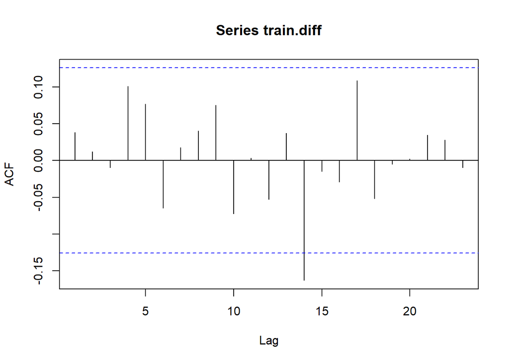

```r
acf(train.diff)
```

Berdasarkan plot tersebut, terlihat bahwa plot ACF *cuts off* pada lag ke 14. Hal ini menandakan data sudah stasioner dalam rataan dan ketidakstasioneran data telah berhasil tertangani.

## Uji ADF

```r
tseries::adf.test(train.diff)
```

```
##
##  Augmented Dickey-Fuller Test
##
## data:  train.diff
## Dickey-Fuller = -5.2828, Lag order = 6, p-value = 0.01
## alternative hypothesis: stationary
```

$H_0$ : Data tidak stasioner dalam rataan

$H_1$ : Data stasioner dalam rataan

Berdasarkan uji ADF tersebut, didapat *p-value* sebesar 0.01 yang lebih kecil dari taraf nyata 5% sehingga tolak $H_0$ atau data stasioner dalam rataan. Hal ini sesuai dengan hasil eksplorasi menggunakan plot data deret waktu dan plot ACF, sehingga dalam hal ini ketidakstasioneran data sudah berhasil ditangani dan dapat dilanjutkan ke pemodelan ARIMAX

## Pemodelan ARIMAX

### Import Data Variabel X

```r
library(readxl)
data_nikel<- read_excel("E:/kuliah/Semester 5/Metode Peramalan Deret Waktu/PraktikumMPDW/ARIMAX-ARCHGARCH/Harga Nikel Berjangka.xlsx")
nikel<- data_nikel$Nikel
nikel<- log(nikel)
```

## Ubah data time series

```r
nikel.ts <- ts(nikel)
```

## Eksplorasi Data

### Plot Penuh Data Deret Waktu

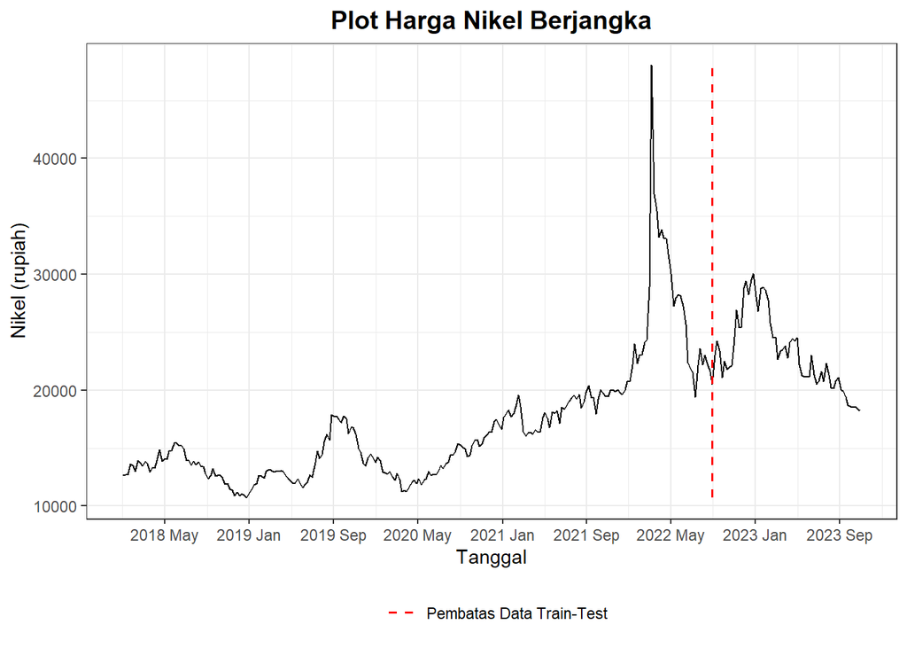

```r
library(ggplot2)

data_nikel$Date <- as.Date(data_nikel$Date)

# Tentukan indeks pembatas antara data train dan data test
index_pemisah <- 244

# Plot menggunakan ggplot2
ggplot(data_nikel, aes(x = Date, y = Nikel)) +
  geom_line() +
  geom_line(data = data.frame(x = data_nikel$Date[index_pemisah], y = range(data_nikel$Nikel)),
            aes(x = x, y = y, color = "Pembatas Data Train-Test"), linetype = "dashed", linewidth = 0.6) +
  scale_x_date(date_breaks = "8 months", date_labels = "%Y %b") +
  labs(title = "Plot Harga Nikel Berjangka", x = "Tanggal", y = "Nikel (rupiah)", color = "") +
  theme_bw() +
  theme(plot.title = element_text(face = "bold", size = 14, hjust = 0.5),
        plot.caption = element_text(hjust = 0.5, size = 12),
        legend.position = "bottom",
        legend.title = element_blank()) +
  scale_color_manual(values = "red", name = "Pembatas Data Train-Test", guide = guide_legend(override.aes = list(size = 1.5)))
```

## Split Data

```r
nikel.train <- nikel[1:244]
nikel.train.ts <- ts(nikel.train)
nikel.test <- nikel[245:305]
nikel.test.ts <- ts(nikel.test)
```

## Plot Data Train Harga Nikel

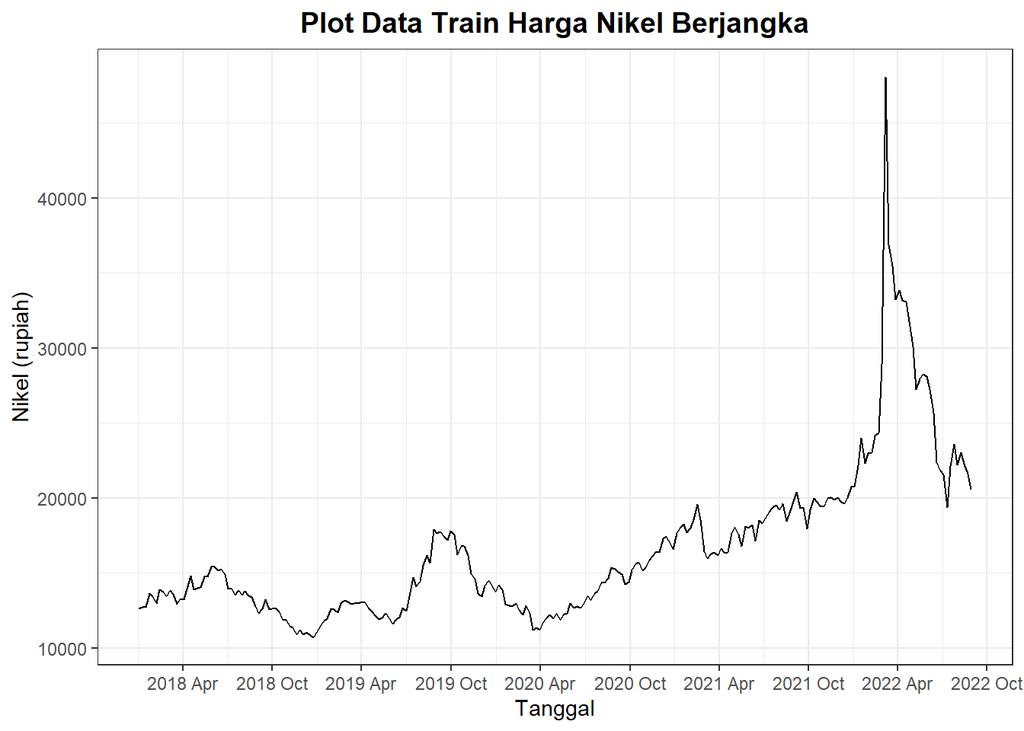

```r
data_nikel.train <- data_nikel[1:244,]
library(ggplot2)
ggplot() +
  geom_line(data = data_nikel.train, aes(x=Date, y=Nikel)) + scale_x_date(date_breaks = "6 months", date_labels = "%Y %b") +
  labs(title = "Plot Data Train Harga Nikel Berjangka", x = "Tanggal", y = "Nikel (rupiah)", color = "Legend") +
  theme_bw() + theme(plot.title = element_text(face = "bold", size = 14, hjust = 0.5),
                     plot.caption = element_text(hjust=0.5, size=12)) +
  scale_color_manual(values = "black")
```

## Plot Data Test Harga Nikel

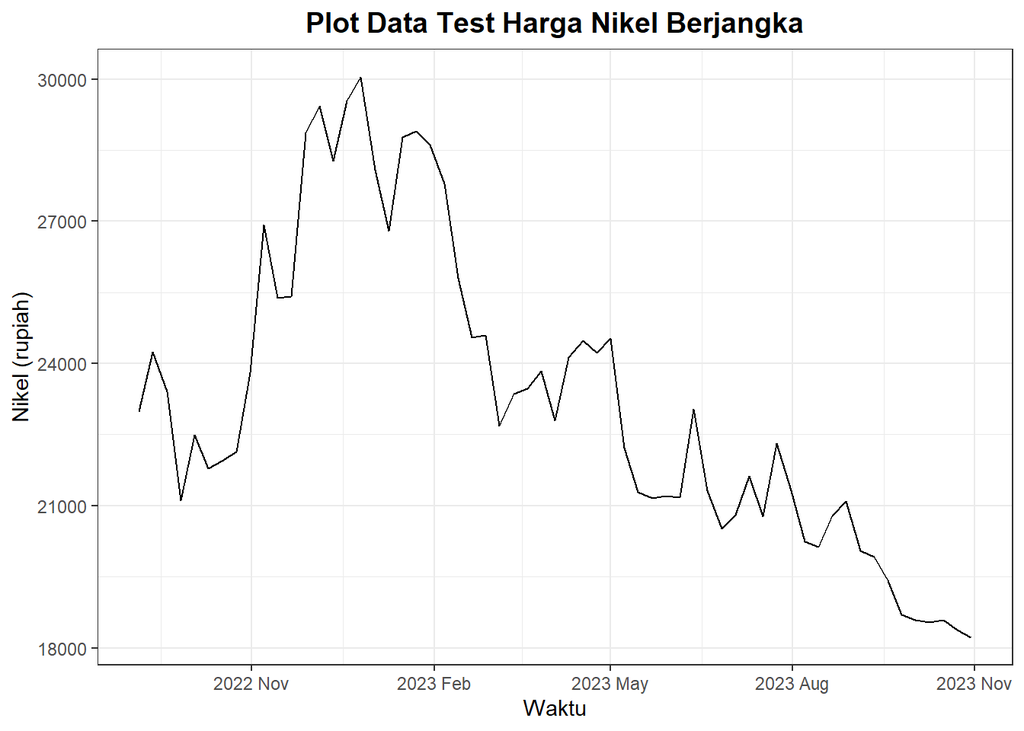

```r
data_nikel.test <- data_nikel[245:305,]
library(ggplot2)
ggplot() +
  geom_line(data = data_nikel.test, aes(x=Date, y=Nikel)) +
  labs(title = "Plot Data Test Harga Nikel Berjangka", x = "Waktu", y = "Nikel (rupiah)", color = "Legend") + scale_x_date(date_breaks = "3 months", date_labels = "%Y %b") +
  theme_bw() + theme(plot.title = element_text(face = "bold", size = 14, hjust = 0.5),
                     plot.caption = element_text(hjust=0.5, size=12)) +
  scale_color_manual(values = "black")
```

## Pembentukan Model Regresi

```r
reg1  <- lm(train.trans~nikel.train)
summary(reg1)
```

```
##
## Call:
## lm(formula = train.trans ~ nikel.train)
##
## Residuals:
##      Min       1Q   Median       3Q      Max
## -1.08522 -0.21662 -0.05979  0.19561  0.76331
##
## Coefficients:
##             Estimate Std. Error t value Pr(>|t|)
## (Intercept) -9.03043    0.71091  -12.70   <2e-16 ***
## nikel.train  1.66481    0.07344   22.67   <2e-16 ***
## ---
## Signif. codes:  0 '***' 0.001 '**' 0.01 '*' 0.05 '.' 0.1 ' ' 1
##
## Residual standard error: 0.3087 on 242 degrees of freedom
## Multiple R-squared:  0.6798, Adjusted R-squared:  0.6785
## F-statistic: 513.9 on 1 and 242 DF,  p-value: < 2.2e-16
```

## Pemodelan Sisaan Model Regresi

### Plot ACF

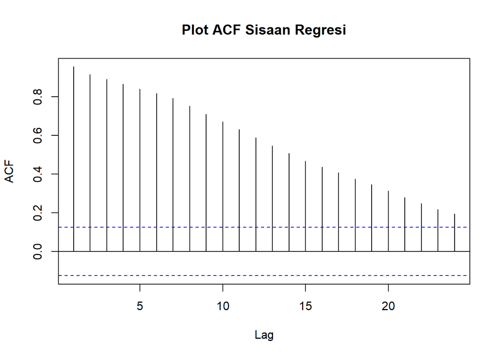

```r
sisaanx <- reg1$residuals
acf(sisaanx, lag.max = 24, main = "Plot ACF Sisaan Regresi")
```

Berdasarkan Plot ACF Sisaan, nilai korelasi antar lag terlihat pada plot di atas menurun secara perlahan (*tails off slowly*). Hal tersebut mengindikasikan bahwa sisaan tidak stasioner dalam rataan. Perlu dilakukan uji formal untuk mengambil kesimpulan kestasioneran data.

## Uji Formal

Secara formal, metode Augmented Dickey-Fuller (ADF) dapat memberikan hasil uji secara akurat untuk menentukan apakah sebuah data stasioner atau tidak. Dengan hipotesis yang diuji sebagai berikut : H0 : Nilai tengah sisaan tidak stasioner H1 : Nilai tengah sisaan stasioner α = 5% = 0.05

```r
tseries::adf.test(sisaanx)
```

```
##
##  Augmented Dickey-Fuller Test
##
## data:  sisaanx
## Dickey-Fuller = -1.8281, Lag order = 6, p-value = 0.6481
## alternative hypothesis: stationary
```

Berdasarkan hasil Augmented Dickey-Fuller Test (ADF Test) didapatkan p-value = 0.6481 > α, maka tak tolak H0. Artinya, tidak cukup bukti untuk mengatakan bahwa sisaan stasioner pada taraf nyata 5%. Sehingga, perlu dilakukan pembedaan sebelum melakukan penentuan model tentatif.

### Penanganan Ketidakstasioneran Data

### Pembedaan sebanyak 1 kali

```r
sisaanx.dif <- diff(sisaanx, difference = 1)
```

### Uji Formal ADF

Pengujian menggunakan Augmented Dickey-Fuller Test H0: Nilai tengah sisaan tidak stasioner H1: Nilai tengah sisaan stasioner α= 5% = 0.05

```r
tseries::adf.test(sisaanx.dif)
```

```
##
##  Augmented Dickey-Fuller Test
##
## data:  sisaanx.dif
## Dickey-Fuller = -5.164, Lag order = 6, p-value = 0.01
## alternative hypothesis: stationary
```

Berdasarkan hasil Augmented Dickey-Fuller Test (ADF Test) didapatkan *p-value* = 0.01 < α, maka tolak $H_0$. Artinya, cukup bukti untuk mengatakan bahwa sisaan sudah stasioner pada taraf nyata 5% setelah dilakukan pembedaan sebanyak 1 kali.

## Identifikasi Model dari Sisaan Model Regresi

### Plot ACF

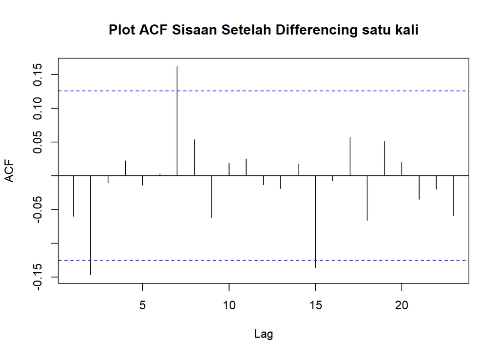

```r
acf(sisaanx.dif, main = "Plot ACF Sisaan Setelah Differencing satu kali")
```

Berdasarkan plot tersebut, terlihat bahwa plot ACF cenderung *cuts off* pada lag 2, sehingga jika plot ACF dianggap tails off. Model tentatifnya ARIMAX(0,1,2)

## Plot PACF

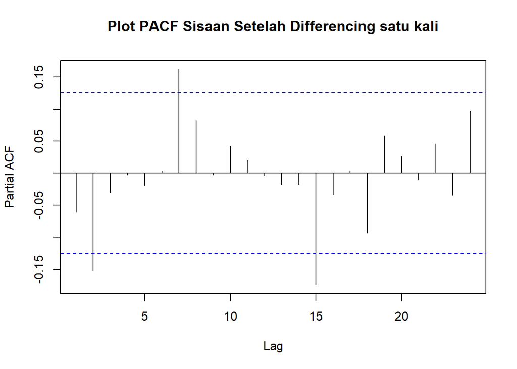

```r
pacf(sisaanx.dif, lag.max = 24, main = "Plot PACF Sisaan Setelah Differencing satu kali")
```

Berdasarkan plot tersebut, terlihat bahwa plot PACF cenderung *cuts off* pada lag ke 2, sehingga jika plot ACF dianggap tails off. Model tentatifnya adalah ARIMAX(2,1,0).

Jika baik plot ACF maupun plot PACF keduanya dianggap *tails off*, maka model yang terbentuk adalah ARIMAX(2,1,2)

## Plot EACF

```r
eacf(sisaanx.dif)
```

```
## AR/MA
##   0 1 2 3 4 5 6 7 8 9 10 11 12 13
## 0 o x o o o o x o o o o  o  o  o
## 1 x x o o o o x o o o o  o  o  o
## 2 x o o o o o o o o o o  o  o  o
## 3 o o o o o o o o o o o  o  o  o
## 4 x x o o o o o o o o o  o  o  o
## 5 x o o o x o o o o o o  o  o  o
## 6 o o o x x x o o o o o  o  o  o
## 7 x x x x o x o o o o o  o  o  o
```

Dari Matriks EACF dapat diduga model yang cocok adalah model ARIMAX(0,1,2) dan ARIMAX(1,1,2)

## Identifikasi Model Tentatif

Berdasarkan plot ACF, PACF, dan EACF, diperoleh 4 model tentatif beserta orde parameternya, sebagai berikut: 1. ARIMAX(0,1,2) 2. ARIMAX(2,1,0) 3. ARIMAX(2,1,2) 4. ARIMAX(1,1,2)

```r
modelx1 <- Arima(train.trans, order = c(0,1,2), xreg = nikel.train, method = "ML")
modelx2 <- Arima(train.trans, order = c(2,1,0), xreg = nikel.train, method = "ML")
modelx3 <- Arima(train.trans, order = c(2,1,2), xreg = nikel.train, method = "ML")
modelx4 <- Arima(train.trans, order = c(1,1,2), xreg = nikel.train, method = "ML")
modelx5 <- Arima(train.trans, order = c(2,1,1), xreg = nikel.train, method = "ML")
```

### ARIMAX(0,1,2)

```r
coeftest(modelx1) #tidak seluruh parameter signifikan
```

```
##
## z test of coefficients:
##
##       Estimate Std. Error z value  Pr(>|z|)
## ma1   0.010806   0.064180  0.1684    0.8663
## ma2  -0.045171   0.061455 -0.7350    0.4623
## xreg  0.625832   0.083355  7.5080 6.002e-14 ***
## ---
## Signif. codes:  0 '***' 0.001 '**' 0.01 '*' 0.05 '.' 0.1 ' ' 1
```

```r
round(modelx1$aic, 3) #-593.226
```

```
## [1] -593.226
```

### ARIMAX(2,1,0)

```r
coeftest(modelx2) #tidak seluruh parameter signifikan
```

```
##
## z test of coefficients:
##
##       Estimate Std. Error z value  Pr(>|z|)
## ar1   0.011621   0.064321  0.1807    0.8566
## ar2  -0.052004   0.065356 -0.7957    0.4262
## xreg  0.627024   0.083388  7.5193 5.506e-14 ***
## ---
## Signif. codes:  0 '***' 0.001 '**' 0.01 '*' 0.05 '.' 0.1 ' ' 1
```

```r
round(modelx2$aic, 3) #-593.313
```

```
## [1] -593.313
```

### ARIMAX(2,1,2)

```r
coeftest(modelx3) #seluruh parameter signifikan
```

```
##
## z test of coefficients:
##
##       Estimate Std. Error   z value  Pr(>|z|)
## ar1   0.074685   0.014581    5.1221 3.022e-07 ***
## ar2  -0.998671   0.003403 -293.4721 < 2.2e-16 ***
## ma1  -0.064430   0.023107   -2.7883  0.005299 **
## ma2   0.999855   0.029172   34.2746 < 2.2e-16 ***
## xreg  0.621467   0.079575    7.8098 5.728e-15 ***
## ---
## Signif. codes:  0 '***' 0.001 '**' 0.01 '*' 0.05 '.' 0.1 ' ' 1
```

```r
round(modelx3$aic, 3) #-595.133
```

```
## [1] -595.133
```

### ARIMAX(1,1,2)

```r
coeftest(modelx4) #tidak seluruh parameter signifikan
```

```
##
## z test of coefficients:
##
##       Estimate Std. Error z value  Pr(>|z|)
## ar1   0.046692   0.681421  0.0685    0.9454
## ma1  -0.035493   0.678576 -0.0523    0.9583
## ma2  -0.045595   0.061111 -0.7461    0.4556
## xreg  0.625801   0.083346  7.5085 5.982e-14 ***
## ---
## Signif. codes:  0 '***' 0.001 '**' 0.01 '*' 0.05 '.' 0.1 ' ' 1
```

```r
round(modelx4$aic, 3) #-591.231
```

```
## [1] -591.231
```

### ARIMAX(2,1,1)

```r
coeftest(modelx5) #tidak seluruh parameter signifikan
```

```
##
## z test of coefficients:
##
##       Estimate Std. Error z value  Pr(>|z|)
## ar1   0.066433   0.603215  0.1101    0.9123
## ar2  -0.052972   0.065598 -0.8075    0.4194
## ma1  -0.055035   0.601562 -0.0915    0.9271
## xreg  0.627192   0.083416  7.5188 5.527e-14 ***
## ---
## Signif. codes:  0 '***' 0.001 '**' 0.01 '*' 0.05 '.' 0.1 ' ' 1
```

```r
round(modelx5$aic, 3) #-591.322
```

```
## [1] -591.322
```

Pada hasil uji signifikansi, hanya ARIMAX (2,1,2) yang seluruh parameternya signifikan. Selain itu ARIMAX (2,1,2) memiliki AIC yang paling kecil dari pada model lainnya yaitu -595.133. Selanjutnya model ARIMAX (2,1,2) akan di-overfitting.

## Overfitting

### ARIMAX(3,1,2)

```r
model1x.over <- Arima(train.trans, order = c(3,1,2), xreg = nikel.train, method = "ML")
coeftest(model1x.over) #tidak seluruh parameter signifikan
```

```
##
## z test of coefficients:
##
##        Estimate Std. Error   z value  Pr(>|z|)
## ar1   0.0760026  0.0686250    1.1075  0.268075
## ar2  -0.9988478  0.0063992 -156.0890 < 2.2e-16 ***
## ar3   0.0010880  0.0654517    0.0166  0.986737
## ma1  -0.0649966  0.0239021   -2.7193  0.006542 **
## ma2   0.9995811  0.0274474   36.4181 < 2.2e-16 ***
## xreg  0.6208861  0.0800326    7.7579 8.634e-15 ***
## ---
## Signif. codes:  0 '***' 0.001 '**' 0.01 '*' 0.05 '.' 0.1 ' ' 1
```

```r
round(model1x.over$aic, 3) #-593.133
```

```
## [1] -593.133
```

### ARIMAX(2,1,3)

```r
model2x.over <- Arima(train.trans, order = c(2,1,3), xreg = nikel.train, method = "ML")
coeftest(model2x.over) #tidak seluruh parameter signifikan
```

```
##
## z test of coefficients:
##
##        Estimate Std. Error   z value  Pr(>|z|)
## ar1   0.0751271  0.0150124    5.0043 5.606e-07 ***
## ar2  -0.9988334  0.0032790 -304.6196 < 2.2e-16 ***
## ma1  -0.0647909  0.0679444   -0.9536    0.3403
## ma2   0.9998321  0.0266764   37.4800 < 2.2e-16 ***
## ma3   0.0006714  0.0677711    0.0099    0.9921
## xreg  0.6213549  0.0800608    7.7610 8.424e-15 ***
## ---
## Signif. codes:  0 '***' 0.001 '**' 0.01 '*' 0.05 '.' 0.1 ' ' 1
```

```r
round(model2x.over$aic, 3) #-593.132
```

```
## [1] -593.132
```

Maka model ARIMAX(2,1,2) tidak terjadi overfitting atau merupakan model yang baik untuk digunakan.

## Diagnostik Model ARIMAX(2,1,2)

```r
sisaan.arimax <- modelx3$residuals
```

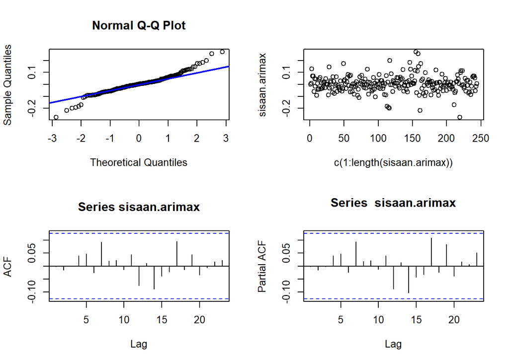

```r
#Eksplorasi
par(mfrow=c(2,2))
qqnorm(sisaan.arimax)
qqline(sisaan.arimax, col = "blue", lwd = 2)
plot(c(1:length(sisaan.arimax)),sisaan.arimax)
acf(sisaan.arimax)
pacf(sisaan.arimax)
```

```r
par(mfrow = c(1,1))
```

### Uji Formal

```r
#1) Sisaan Menyebar Normal
ks.test(sisaan.arimax,"pnorm")  #tak tolak H0 > sisaan menyebar normal
```

```
##
##  Asymptotic one-sample Kolmogorov-Smirnov test
##
## data:  sisaan.arimax
## D = 0.43184, p-value < 2.2e-16
## alternative hypothesis: two-sided
```

Pada tahapan ini uji formal yang digunakan untuk normalitas adalah uji Kolmogorov-Smirnov (KS). Hipotesis pada uji KS adalah sebagai berikut.

$H_0$ : Sisaan menyebar normal

$H_1$ : Sisaan tidak menyebar normal

Berdasarkan uji Kolmogorov-Smirnov tersebut, didapat *p-value* sebesar < 2.2e-16 yang kurang dari taraf nyata 5% sehingga tolak $H_0$ dan menandakan bahwa sisaan tidak menyebar normal.

```r
#2) Sisaan saling bebas/tidak ada autokorelasi
Box.test(sisaan.arimax, type = "Ljung")  #tak tolak H0 > sisaan saling bebas
```

```
##
##  Box-Ljung test
##
## data:  sisaan.arimax
## X-squared = 0.00077284, df = 1, p-value = 0.9778
```

Selanjutnya akan dilakukan uji formal untuk kebebasan sisaan menggunakan uji Ljung-Box. Hipotesis yang digunakan adalah sebagai berikut.

$H_0$ : Sisaan saling bebas

$H_1$ : Sisaan tidak tidak saling bebas

Berdasarkan uji Ljung-Box tersebut, didapat *p-value* sebesar 0.9778 yang lebih besar dari taraf nyata 5% sehingga tak tolak $H_0$ dan menandakan bahwa sisaan saling bebas.

```r
#3) Sisaan homogen
Box.test((sisaan.arimax)^2, type = "Ljung")  #tak tolak H0 > sisaan homogen
```

```
##
##  Box-Ljung test
##
## data:  (sisaan.arimax)^2
## X-squared = 13.616, df = 1, p-value = 0.0002243
```

Hipotesis yang digunakan untuk uji kehomogenan ragam adalah sebagai berikut.

$H_0$ : Ragam sisaan homogen

$H_1$ : Ragam sisaan tidak homogen

Berdasarkan uji Ljung-Box terhadap sisaan kuadrat tersebut, didapat *p-value* sebesar 0.0002243 yang kurang dari taraf nyata 5% sehingga tolak $H_0$ dan menandakan bahwa ragam sisaan tidak homogen.

```r
#4) Nilai tengah sisaan sama dengan nol
t.test(sisaan.arimax, mu = 0, conf.level = 0.95)  #tak tolak h0 > nilai tengah sisaan sama dengan 0
```

```
##
##  One Sample t-test
##
## data:  sisaan.arimax
## t = 0.71694, df = 243, p-value = 0.4741
## alternative hypothesis: true mean is not equal to 0
## 95 percent confidence interval:
##  -0.005518353  0.011834213
## sample estimates:
##  mean of x
## 0.00315793
```

Terakhir, dengan uji-t, akan dicek apakah nilai tengah sisaan sama dengan nol. Hipotesis yang diujikan sebagai berikut.

$H_0$ : nilai tengah sisaan sama dengan 0

$H_1$ : nilai tengah sisaan tidak sama dengan 0

Berdasarkan uji-t tersebut, didapat *p-value* sebesar 0.4741 yang lebih besar dari taraf nyata 5% sehingga tak tolak $H_0$ dan menandakan bahwa nilai tengah sisaan sama dengan nol.

## Forecasting

```r
ramalan.arimax <- forecast::forecast((modelx3), xreg = nikel.test)
data.ramalan.arimax<- ramalan.arimax$mean
ramalan.arimax <- predict(modelx3,  n.ahead = 61, newxreg = data.frame(nikel.test))
```

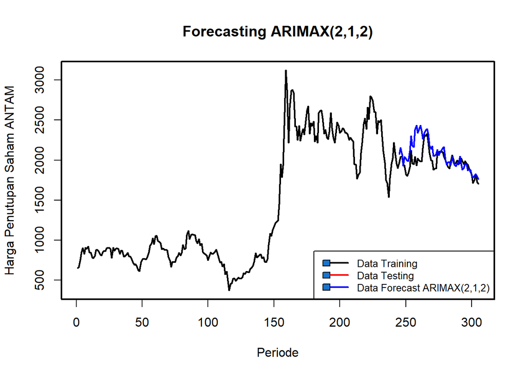

```r
pt_2 <- train.trans[length(train.trans)] #nilai akhir data latih
hasil.forc.Diff2 <- ramalan.arimax$pred
hasil <- diffinv(hasil.forc.Diff2, differences = 1) + pt_2
Hasil3 <- exp(hasil.forc.Diff2)
ts.plot(data.ts,xlab = "Periode", ylab = "Harga Penutupan Saham ANTAM", col="black",lwd=2,main="Forecasting ARIMAX(2,1,2)",gpars = list(col.main="black",col.axis="black",col.sub="black"))
lines(Hasil3, col = "blue",lwd=2)
legend("bottomright", 100,20,legend = c("Data Training", "Data Testing", "Data Forecast ARIMAX(2,1,2)"),
       lwd=2, col=c("black","red","blue"), cex=0.8)
box(col="black",lwd=2)
```

## Akurasi

```r
perbandingan.da2<-matrix(data=c(head(data.ts.test, n=61), Hasil3),
                     nrow = 61, ncol = 2)
colnames(perbandingan.da2)<-c("Aktual","Hasil Forecast")
perbandingan.da2
```

```
##       Aktual Hasil Forecast
##  [1,]   1975       2075.182
##  [2,]   2040       2153.119
##  [3,]   2040       2070.205
##  [4,]   1940       1931.168
##  [5,]   1935       2043.145
##  [6,]   1820       2015.673
##  [7,]   1800       1992.394
##  [8,]   1835       1987.599
##  [9,]   1915       2113.254
## [10,]   2120       2301.166
## [11,]   1960       2184.917
## [12,]   1950       2164.970
## [13,]   2040       2377.139
## [14,]   1935       2432.867
```

[output cut: 47 more lines]

```r
library(generics)
accuracy(ts(Hasil3), head(data.ts.test, n=61))
```

```
##                 ME    RMSE      MAE       MPE    MAPE
## Test set -89.66722 157.927 110.3223 -4.568394 5.60772
```

Didapatkan, nilai MAPE sebesar 5.60772 pada model ARIMAX(2,1,2)

### Uji ARCH-Lagrange Multiplier (ARCH-LM)

```r
for (i in 1:20) {
  ArchTest <- ArchTest(sisaan.arimax, lags=i, demean=TRUE)
  cat("P Value LM Test lag ke", i,"adalah" , ArchTest$p.value, "\n") }
```

```
## P Value LM Test lag ke 1 adalah 0.0003353504
## P Value LM Test lag ke 2 adalah 0.0004363277
## P Value LM Test lag ke 3 adalah 3.961769e-06
## P Value LM Test lag ke 4 adalah 9.077819e-06
## P Value LM Test lag ke 5 adalah 2.977216e-06
## P Value LM Test lag ke 6 adalah 8.160813e-06
## P Value LM Test lag ke 7 adalah 2.054464e-05
## P Value LM Test lag ke 8 adalah 1.860779e-05
## P Value LM Test lag ke 9 adalah 4.427708e-05
## P Value LM Test lag ke 10 adalah 4.484755e-05
## P Value LM Test lag ke 11 adalah 7.990891e-05
## P Value LM Test lag ke 12 adalah 0.000147735
## P Value LM Test lag ke 13 adalah 0.0002954256
## P Value LM Test lag ke 14 adalah 0.0005721714
## P Value LM Test lag ke 15 adalah 0.0009989575
## P Value LM Test lag ke 16 adalah 0.001703387
## P Value LM Test lag ke 17 adalah 0.002042228
## P Value LM Test lag ke 18 adalah 0.002971045
## P Value LM Test lag ke 19 adalah 0.003937561
## P Value LM Test lag ke 20 adalah 0.00645564
```

Setelah dilakukan uji efek ARCH untuk 20 lag awal, semua nilai p-value menunjukkan signifikan, sehingga akan dicoba dengan GARCH.

## Pemodelan GARCH

```r
train.diff.ts <- ts(train.diff)
nikel.train.diff <- diff(nikel.train)
matrix_nikel_train_diff <- as.matrix(nikel.train.diff)
nikel.test.diff <- diff(nikel.test)
matrix_nikel_test_diff <- as.matrix(nikel.test.diff)
```

```r
# Model ARIMAX(2,1,2)-GARCH(1,1)
garch11diffc <- rugarch::ugarchspec(mean.model = list(armaOrder = c(2,2), external.regressors = matrix_nikel_train_diff, include.mean = FALSE),
                     variance.model = list(model = "sGARCH",garchOrder=c(1,1)))
garch11Fittdiff <- ugarchfit(spec=garch11diffc, data=train.diff)
garch11Fittdiff
```

```
##
## *---------------------------------*
## *          GARCH Model Fit        *
## *---------------------------------*
##
## Conditional Variance Dynamics
## -----------------------------------
## GARCH Model  : sGARCH(1,1)
## Mean Model   : ARFIMA(2,0,2)
## Distribution : norm
##
## Optimal Parameters
## ------------------------------------
##         Estimate  Std. Error    t value Pr(>|t|)
## ar1     1.784697    0.025742    69.3305 0.000000
## ar2    -0.950746    0.024753   -38.4092 0.000000
## ma1    -1.837086    0.001122 -1636.7792 0.000000
## ma2     1.003337    0.001776   565.0063 0.000000
## mxreg1  0.632119    0.081803     7.7273 0.000000
## omega   0.001364    0.000474     2.8759 0.004029
## alpha1  0.255805    0.091422     2.7981 0.005141
## beta1   0.456621    0.127774     3.5736 0.000352
##
## Robust Standard Errors:
##         Estimate  Std. Error   t value Pr(>|t|)
## ar1     1.784697    0.045779   38.9849 0.000000
## ar2    -0.950746    0.042488  -22.3766 0.000000
## ma1    -1.837086    0.002093 -877.6634 0.000000
## ma2     1.003337    0.002215  453.0006 0.000000
## mxreg1  0.632119    0.223521    2.8280 0.004684
## omega   0.001364    0.000671    2.0344 0.041907
## alpha1  0.255805    0.134407    1.9032 0.057014
## beta1   0.456621    0.121946    3.7444 0.000181
##
## LogLikelihood : 320.8922
##
## Information Criteria
## ------------------------------------
##
## Akaike       -2.5752
```

[output cut: 49 more lines]

```
## Negative Sign Bias 0.06648 0.9471
## Positive Sign Bias 0.44542 0.6564
## Joint Effect       1.00055 0.8011
##
##
## Adjusted Pearson Goodness-of-Fit Test:
## ------------------------------------
##   group statistic p-value(g-1)
## 1    20     30.99     0.040457
## 2    30     51.94     0.005538
## 3    40     53.46     0.061363
## 4    50     61.32     0.111338
##
##
## Elapsed time : 0.2613859
```

Setelah dilakukan trial and error pada model ARIMAX-GARCH, didapatkan model terbaik yaitu ARIMAX(2,1,2)-GARCH(1,1) dengan parameter yang seluruhnya signifikan pada taraf nyata 5%, ARCH LM yang sudah tidak signifikan, dan memiliki nilai AIC yang kecil sebesar -2.5752.

## Overfitting

```r
# Model ARIMAX(2,1,2)-GARCH(2,1)
garch21diffc <- rugarch::ugarchspec(mean.model = list(armaOrder = c(2,2), external.regressors = matrix_nikel_train_diff, include.mean = FALSE),
                     variance.model = list(model = "sGARCH",garchOrder=c(2,1)))
garch21Fittdiff <- ugarchfit(spec=garch21diffc, data=train.diff)
garch21Fittdiff
```

```
##
## *---------------------------------*
## *          GARCH Model Fit        *
## *---------------------------------*
##
## Conditional Variance Dynamics
## -----------------------------------
## GARCH Model  : sGARCH(2,1)
## Mean Model   : ARFIMA(2,0,2)
## Distribution : norm
##
## Optimal Parameters
## ------------------------------------
##         Estimate  Std. Error   t value Pr(>|t|)
## ar1     0.084840    0.033413   2.53911 0.011114
## ar2    -0.985294    0.017696 -55.67944 0.000000
## ma1    -0.068859    0.038932  -1.76871 0.076943
## ma2     0.976697    0.020693  47.20037 0.000000
## mxreg1  0.555603    0.076276   7.28408 0.000000
## omega   0.001858    0.000637   2.91811 0.003522
## alpha1  0.198391    0.082987   2.39063 0.016819
## alpha2  0.087756    0.109542   0.80111 0.423066
## beta1   0.309645    0.202533   1.52886 0.126299
##
## Robust Standard Errors:
##         Estimate  Std. Error   t value Pr(>|t|)
## ar1     0.084840    0.031133   2.72508 0.006429
## ar2    -0.985294    0.011373 -86.63427 0.000000
## ma1    -0.068859    0.036302  -1.89681 0.057853
## ma2     0.976697    0.017235  56.66924 0.000000
## mxreg1  0.555603    0.233567   2.37878 0.017370
## omega   0.001858    0.000596   3.11580 0.001834
## alpha1  0.198391    0.117876   1.68305 0.092365
## alpha2  0.087756    0.122253   0.71782 0.472867
## beta1   0.309645    0.177625   1.74325 0.081290
##
## LogLikelihood : 319.917
##
## Information Criteria
## ------------------------------------
```

[output cut: 52 more lines]

```
## Negative Sign Bias  0.3508 0.7260
## Positive Sign Bias  0.4380 0.6618
## Joint Effect        1.5323 0.6748
##
##
## Adjusted Pearson Goodness-of-Fit Test:
## ------------------------------------
##   group statistic p-value(g-1)
## 1    20     24.74      0.16940
## 2    30     39.10      0.09979
## 3    40     42.93      0.30664
## 4    50     64.20      0.07128
##
##
## Elapsed time : 0.532198
```

Pada model ARIMAX(2,1,2)-GARCH(2,1) tidak seluruh parameternya signifikan, ARCH LM tidak signifikan, AIC sebesar -2.5590

```r
# Model ARIMAX(2,1,2)-GARCH(1,2)
garch12diffc <- rugarch::ugarchspec(mean.model = list(armaOrder = c(2,2), external.regressors = matrix_nikel_train_diff, include.mean = FALSE),
                     variance.model = list(model = "sGARCH",garchOrder=c(1,2)))
garch12Fittdiff <- ugarchfit(spec=garch12diffc, data=train.diff)
garch12Fittdiff
```

```
##
## *---------------------------------*
## *          GARCH Model Fit        *
## *---------------------------------*
##
## Conditional Variance Dynamics
## -----------------------------------
## GARCH Model  : sGARCH(1,2)
## Mean Model   : ARFIMA(2,0,2)
## Distribution : norm
##
## Optimal Parameters
## ------------------------------------
##         Estimate  Std. Error    t value Pr(>|t|)
## ar1     1.784697    0.025510    69.9612 0.000000
## ar2    -0.950746    0.024488   -38.8253 0.000000
## ma1    -1.837086    0.001122 -1636.9741 0.000000
## ma2     1.003337    0.001773   565.8571 0.000000
## mxreg1  0.632119    0.076805     8.2302 0.000000
## omega   0.001364    0.000470     2.9038 0.003686
## alpha1  0.255799    0.091021     2.8103 0.004949
## beta1   0.456622    0.204821     2.2294 0.025789
## beta2   0.000000    0.227419     0.0000 1.000000
##
## Robust Standard Errors:
##         Estimate  Std. Error   t value Pr(>|t|)
## ar1     1.784697    0.044331   40.2588 0.000000
## ar2    -0.950746    0.041067  -23.1509 0.000000
## ma1    -1.837086    0.002088 -879.9106 0.000000
## ma2     1.003337    0.002185  459.0945 0.000000
## mxreg1  0.632119    0.204370    3.0930 0.001981
## omega   0.001364    0.000660    2.0664 0.038788
## alpha1  0.255799    0.130576    1.9590 0.050111
## beta1   0.456622    0.340344    1.3416 0.179710
## beta2   0.000000    0.278197    0.0000 1.000000
##
## LogLikelihood : 320.8922
##
## Information Criteria
## ------------------------------------
```

[output cut: 52 more lines]

```
## Negative Sign Bias 0.06646 0.9471
## Positive Sign Bias 0.44540 0.6564
## Joint Effect       1.00053 0.8011
##
##
## Adjusted Pearson Goodness-of-Fit Test:
## ------------------------------------
##   group statistic p-value(g-1)
## 1    20     30.99     0.040457
## 2    30     51.94     0.005538
## 3    40     53.46     0.061363
## 4    50     61.32     0.111338
##
##
## Elapsed time : 0.2450881
```

Pada model ARIMAX(2,1,2)-GARCH(1,2) tidak seluruh parameternya signifikan, ARCH LM tidak signifikan, AIC sebesar -2.5670. Maka, model terbaik tetap ARIMAX(2,1,2)-GARCH(1,1)

## Uji Diagnostik model ARIMAX(2,1,2)-GARCH(1,1)

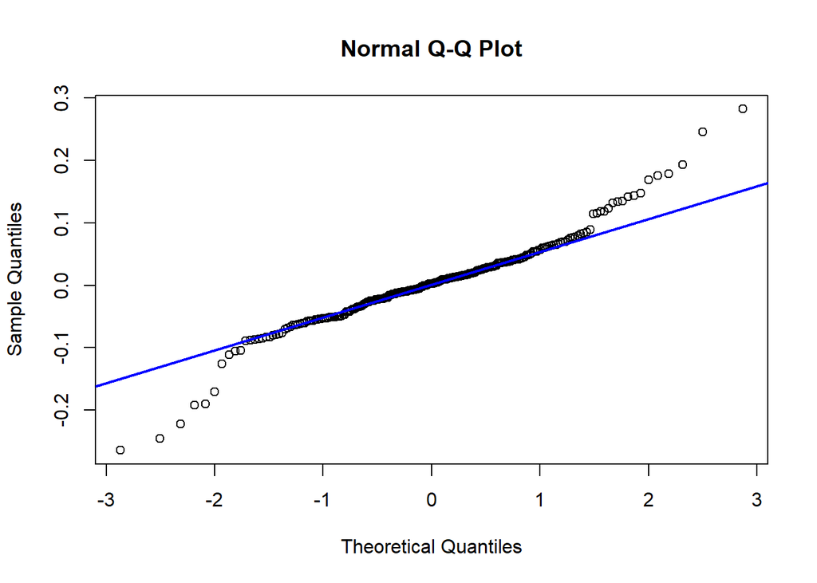

```r
sisaan.akhir <- garch11Fittdiff@fit[["residuals"]]
qqnorm(sisaan.akhir)
qqline(sisaan.akhir , col = "blue", lwd = 2)
```

```r
# Uji Formal
#1) Uji Normalitas
ks.test(sisaan.akhir,"pnorm")  #tak tolak H0 > sisaan menyebar normal
```

```
##
##  Asymptotic one-sample Kolmogorov-Smirnov test
##
## data:  sisaan.akhir
## D = 0.42674, p-value < 2.2e-16
## alternative hypothesis: two-sided
```

```r
#tolak H0 -> sisaan tidak menyebar normal

#2) Uji Kebebasan
Box.test(sisaan.akhir , type = "Ljung")
```

```
##
##  Box-Ljung test
##
## data:  sisaan.akhir
## X-squared = 0.37107, df = 1, p-value = 0.5424
```

```r
#tak tolak H0 -> sisaan saling bebas

#3) Uji Nilai tengah sisaan = 0
t.test(sisaan.akhir, mu = 0, conf.level = 0.95)
```

```
##
##  One Sample t-test
##
## data:  sisaan.akhir
## t = 0.67805, df = 242, p-value = 0.4984
## alternative hypothesis: true mean is not equal to 0
## 95 percent confidence interval:
##  -0.00576441  0.01181594
## sample estimates:
##   mean of x
## 0.003025765
```

```r
#tak tolak h0 -> nilai tengah sisaan sama dengan 0
```

## Forecasting dengan model ARIMAX(2,1,2)-GARCH(1,1)

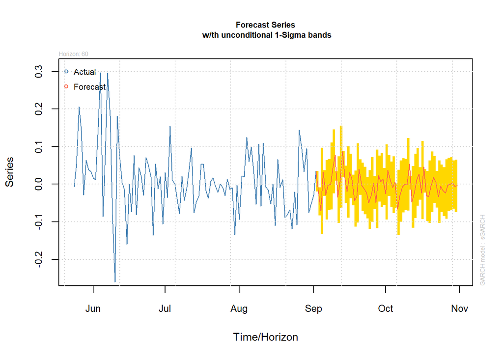

```r
forc<- ugarchforecast(fitORspec = garch11Fittdiff, n.ahead = 60, n.roll = 0, external.forecasts = list(mregfor = matrix_nikel_test_diff, vregfor = NULL))
plot(forc, which= 1)
```

```r
pt_1 <- train.trans[244] #nilai akhir data latih
hasil.forc.Diff <- forc@forecast$seriesFor[,1]
hasilgarch <- diffinv(hasil.forc.Diff, differences = 1) + pt_1
hasilyoo <- hasilgarch
hasilakhir <- exp(hasilyoo)
perbandingan <- data.frame("Aktual"= data.test$Close,
                           "Ramalan" = hasilakhir)
head(perbandingan,10)
```

```
##    Aktual  Ramalan
## 1    1975 1900.000
## 2    2040 1968.021
## 3    2040 1921.023
## 4    1940 1790.336
## 5    1935 1850.431
## 6    1820 1799.184
## 7    1800 1795.080
## 8    1835 1794.677
## 9    1915 1873.897
## 10   2120 2025.201
```

## MAPE Data Uji

```r
Date<-c(data.test$Date)
dataframe <- data.frame(Date, perbandingan)
T <- nrow(dataframe)
MAPE <- 1/T*sum(abs((dataframe$Aktual-dataframe$Ramalan)/dataframe$Aktual)*100)
MAPE
```

```
## [1] 7.206366
```

## Validasi Model

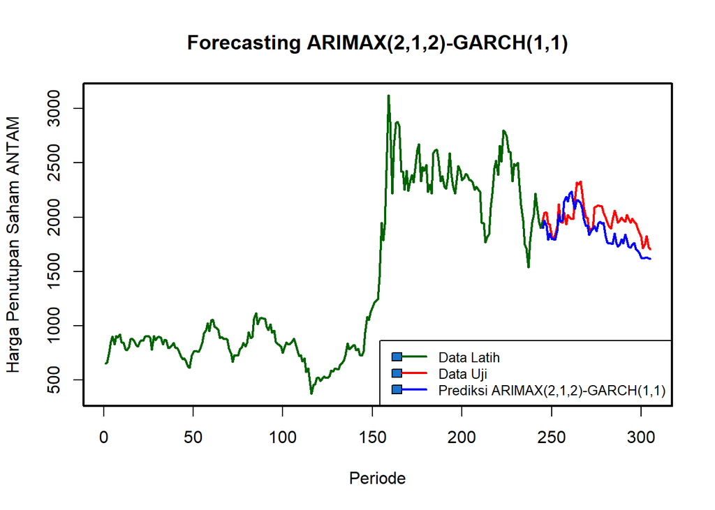

```r
plot(data.ts, xlab = "Periode", ylab = "Harga Penutupan Saham ANTAM", col = "darkgreen", lwd = 2, main = "Forecasting ARIMAX(2,1,2)-GARCH(1,1)", type = "l")
lines(245:length(data.ts), data.ts[245:length(data.ts)], col = "red", lwd = 2)
lines(245:length(data.ts), hasilakhir, col = "blue", lwd = 2)
legend("bottomright", 100, 20, legend = c("Data Latih", "Data Uji", "Prediksi ARIMAX(2,1,2)-GARCH(1,1)"),
       lwd = 2, col = c("darkgreen", "red", "blue"), cex = 0.8)
box(col = "black", lwd = 2)
```